# Risk Factor Analysis

## Outcome Variable

**Outcome Variable:** ever_wasted

## Predictor Variables

**Intervention Variable:** fhtcm

**Adjustment Set:**

- arm
- W_mage
- W_fage
- meducyrs
- feducyrs
- W_mhtcm
- W_mwtkg
- W_mbmi
- single
- delta_W_mage
- delta_W_fage
- delta_meducyrs
- delta_feducyrs
- delta_W_mhtcm
- delta_W_mwtkg
- delta_W_mbmi
- delta_single

## Stratifying Variables

The analysis was stratified on these variable(s):

- agecat
- studyid
- country

## Data Summary

| agecat | studyid | country | fhtcm | ever_wasted | n_cell | n |
| --- | --- | --- | --- | --- | --- | --- |
| 0-24 months | COHORTS | GUATEMALA | >=167 cm | 0 | 54 | 495 |
| 0-24 months | COHORTS | GUATEMALA | >=167 cm | 1 | 9 | 495 |
| 0-24 months | COHORTS | GUATEMALA | <162 cm | 0 | 224 | 495 |
| 0-24 months | COHORTS | GUATEMALA | <162 cm | 1 | 69 | 495 |
| 0-24 months | COHORTS | GUATEMALA | [162-167) cm | 0 | 105 | 495 |
| 0-24 months | COHORTS | GUATEMALA | [162-167) cm | 1 | 34 | 495 |
| 0-24 months | Keneba | GAMBIA | >=167 cm | 0 | 674 | 1933 |
| 0-24 months | Keneba | GAMBIA | >=167 cm | 1 | 574 | 1933 |
| 0-24 months | Keneba | GAMBIA | <162 cm | 0 | 69 | 1933 |
| 0-24 months | Keneba | GAMBIA | <162 cm | 1 | 63 | 1933 |
| 0-24 months | Keneba | GAMBIA | [162-167) cm | 0 | 291 | 1933 |
| 0-24 months | Keneba | GAMBIA | [162-167) cm | 1 | 262 | 1933 |
| 0-24 months | PROBIT | BELARUS | >=167 cm | 0 | 8475 | 12537 |
| 0-24 months | PROBIT | BELARUS | >=167 cm | 1 | 3269 | 12537 |
| 0-24 months | PROBIT | BELARUS | <162 cm | 0 | 115 | 12537 |
| 0-24 months | PROBIT | BELARUS | <162 cm | 1 | 53 | 12537 |
| 0-24 months | PROBIT | BELARUS | [162-167) cm | 0 | 454 | 12537 |
| 0-24 months | PROBIT | BELARUS | [162-167) cm | 1 | 171 | 12537 |
| 0-24 months | SAS-CompFeed | INDIA | >=167 cm | 0 | 255 | 895 |
| 0-24 months | SAS-CompFeed | INDIA | >=167 cm | 1 | 152 | 895 |
| 0-24 months | SAS-CompFeed | INDIA | <162 cm | 0 | 130 | 895 |
| 0-24 months | SAS-CompFeed | INDIA | <162 cm | 1 | 96 | 895 |
| 0-24 months | SAS-CompFeed | INDIA | [162-167) cm | 0 | 145 | 895 |
| 0-24 months | SAS-CompFeed | INDIA | [162-167) cm | 1 | 117 | 895 |
| 0-24 months | SAS-FoodSuppl | INDIA | >=167 cm | 0 | 53 | 399 |
| 0-24 months | SAS-FoodSuppl | INDIA | >=167 cm | 1 | 53 | 399 |
| 0-24 months | SAS-FoodSuppl | INDIA | <162 cm | 0 | 75 | 399 |
| 0-24 months | SAS-FoodSuppl | INDIA | <162 cm | 1 | 88 | 399 |
| 0-24 months | SAS-FoodSuppl | INDIA | [162-167) cm | 0 | 83 | 399 |
| 0-24 months | SAS-FoodSuppl | INDIA | [162-167) cm | 1 | 47 | 399 |

[output cut: 60 more lines]

The following strata were considered:

- agecat: 0-24 months, studyid: COHORTS, country: GUATEMALA
- agecat: 0-24 months, studyid: Keneba, country: GAMBIA
- agecat: 0-24 months, studyid: PROBIT, country: BELARUS
- agecat: 0-24 months, studyid: SAS-CompFeed, country: INDIA
- agecat: 0-24 months, studyid: SAS-FoodSuppl, country: INDIA
- agecat: 0-6 months, studyid: COHORTS, country: GUATEMALA
- agecat: 0-6 months, studyid: Keneba, country: GAMBIA
- agecat: 0-6 months, studyid: PROBIT, country: BELARUS
- agecat: 0-6 months, studyid: SAS-CompFeed, country: INDIA
- agecat: 0-6 months, studyid: SAS-FoodSuppl, country: INDIA
- agecat: 6-24 months, studyid: COHORTS, country: GUATEMALA
- agecat: 6-24 months, studyid: Keneba, country: GAMBIA
- agecat: 6-24 months, studyid: PROBIT, country: BELARUS
- agecat: 6-24 months, studyid: SAS-CompFeed, country: INDIA
- agecat: 6-24 months, studyid: SAS-FoodSuppl, country: INDIA

### Dropped Strata

Some strata were dropped due to rare outcomes:

- agecat: 0-6 months, studyid: COHORTS, country: GUATEMALA
- agecat: 6-24 months, studyid: PROBIT, country: BELARUS

## Methods Detail

We're interested in the causal parameters $E[Y_a]$ for all values of $a \in \mathcal{A}$. These parameters represent the mean outcome if, possibly contrary to fact, we intervened to set all units to have $A=a$. Under the randomization and positivity assumptions, these are identified by the statistical parameters $\psi_a=E_W[E_{Y|A,W}(Y|A=a,W)]$. In addition, we're interested in the mean of $Y$, $E[Y]$ under no intervention (the observed mean). We will estimate these parameters by using SuperLearner to fit the relevant likelihood factors -- $E_{Y|A,W}(Y|A=a,W)$ and $p(A=a|W)$, and then updating our likelihood fit using a joint TMLE.

For unadjusted analyses ($W=\{\}$), initial likelihoods were estimated using Lrnr_glm to estimate the simple $E(Y|A)$ and Lrnr_mean to estimate $p(A)$. For adjusted analyses, a small library containing Lrnr_glmnet, Lrnr_xgboost, and Lrnr_mean was used.

Having estimated these parameters, we will then use the delta method to estimate relative risks and attributable risks relative to a prespecified baseline level of $A$.

# Results Detail

## Results Plots

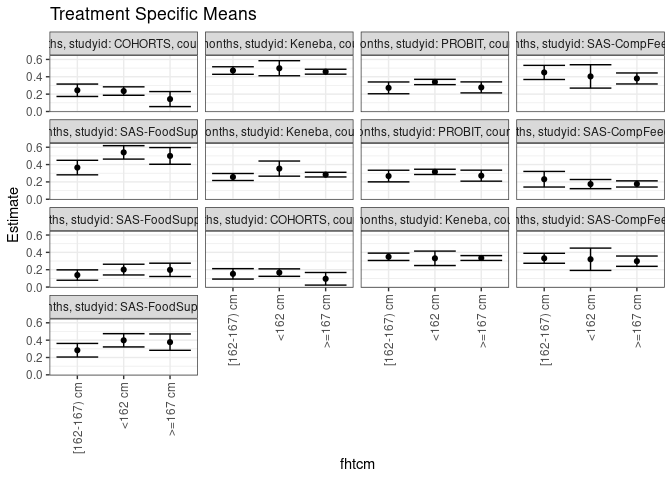

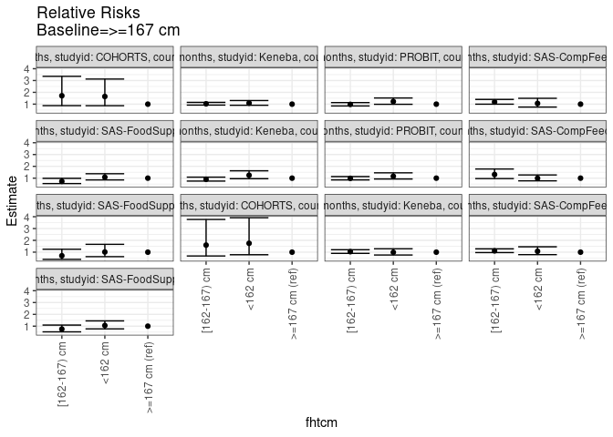

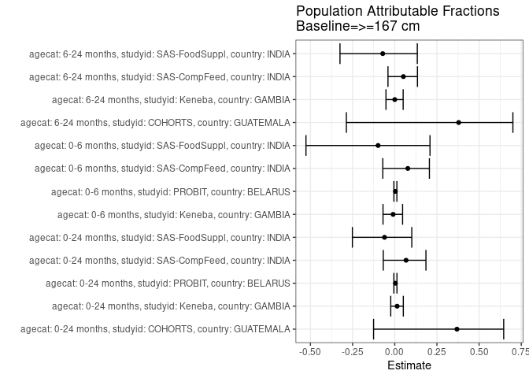

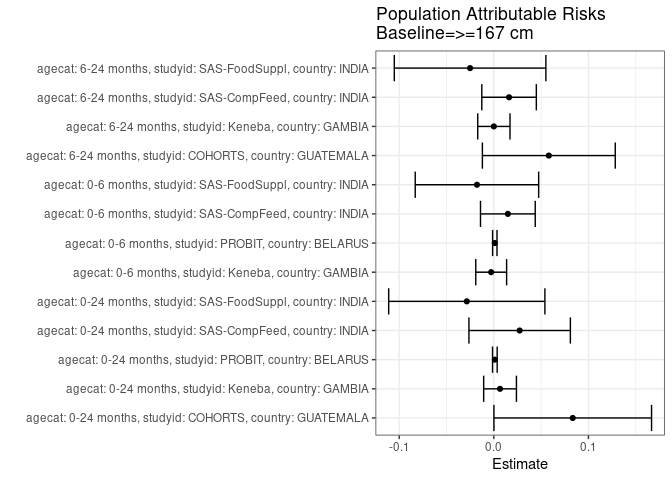

## Results Table

### Parameter: TSM

| agecat | studyid | country | intervention_level | baseline_level | estimate | ci_lower | ci_upper |
| --- | --- | --- | --- | --- | --- | --- | --- |
| 0-24 months | COHORTS | GUATEMALA | >=167 cm | NA | 0.1428571 | 0.0563614 | 0.2293528 |
| 0-24 months | COHORTS | GUATEMALA | <162 cm | NA | 0.2354949 | 0.1868615 | 0.2841282 |
| 0-24 months | COHORTS | GUATEMALA | [162-167) cm | NA | 0.2446043 | 0.1730725 | 0.3161361 |
| 0-24 months | Keneba | GAMBIA | >=167 cm | NA | 0.4584908 | 0.4301080 | 0.4868736 |
| 0-24 months | Keneba | GAMBIA | <162 cm | NA | 0.4984904 | 0.4117630 | 0.5852178 |
| 0-24 months | Keneba | GAMBIA | [162-167) cm | NA | 0.4720725 | 0.4286673 | 0.5154777 |
| 0-24 months | PROBIT | BELARUS | >=167 cm | NA | 0.2775132 | 0.2142360 | 0.3407905 |
| 0-24 months | PROBIT | BELARUS | <162 cm | NA | 0.3401032 | 0.3095252 | 0.3706813 |
| 0-24 months | PROBIT | BELARUS | [162-167) cm | NA | 0.2720750 | 0.2039877 | 0.3401624 |
| 0-24 months | SAS-CompFeed | INDIA | >=167 cm | NA | 0.3805118 | 0.3172491 | 0.4437744 |
| 0-24 months | SAS-CompFeed | INDIA | <162 cm | NA | 0.4041524 | 0.2695138 | 0.5387910 |
| 0-24 months | SAS-CompFeed | INDIA | [162-167) cm | NA | 0.4501385 | 0.3689067 | 0.5313703 |
| 0-24 months | SAS-FoodSuppl | INDIA | >=167 cm | NA | 0.4997495 | 0.4035434 | 0.5959557 |
| 0-24 months | SAS-FoodSuppl | INDIA | <162 cm | NA | 0.5405575 | 0.4632612 | 0.6178538 |
| 0-24 months | SAS-FoodSuppl | INDIA | [162-167) cm | NA | 0.3655898 | 0.2817065 | 0.4494730 |
| 0-6 months | Keneba | GAMBIA | >=167 cm | NA | 0.2839430 | 0.2569060 | 0.3109801 |
| 0-6 months | Keneba | GAMBIA | <162 cm | NA | 0.3537177 | 0.2664190 | 0.4410165 |
| 0-6 months | Keneba | GAMBIA | [162-167) cm | NA | 0.2566567 | 0.2162251 | 0.2970883 |
| 0-6 months | PROBIT | BELARUS | >=167 cm | NA | 0.2719983 | 0.2085041 | 0.3354924 |
| 0-6 months | PROBIT | BELARUS | <162 cm | NA | 0.3160524 | 0.2857710 | 0.3463337 |
| 0-6 months | PROBIT | BELARUS | [162-167) cm | NA | 0.2678572 | 0.2007301 | 0.3349843 |
| 0-6 months | SAS-CompFeed | INDIA | >=167 cm | NA | 0.1765934 | 0.1410786 | 0.2121081 |
| 0-6 months | SAS-CompFeed | INDIA | <162 cm | NA | 0.1751496 | 0.1222201 | 0.2280790 |
| 0-6 months | SAS-CompFeed | INDIA | [162-167) cm | NA | 0.2309799 | 0.1408743 | 0.3210856 |
| 0-6 months | SAS-FoodSuppl | INDIA | >=167 cm | NA | 0.1982841 | 0.1215239 | 0.2750443 |
| 0-6 months | SAS-FoodSuppl | INDIA | <162 cm | NA | 0.2013488 | 0.1394389 | 0.2632586 |
| 0-6 months | SAS-FoodSuppl | INDIA | [162-167) cm | NA | 0.1384500 | 0.0786623 | 0.1982377 |
| 6-24 months | COHORTS | GUATEMALA | >=167 cm | NA | 0.0952381 | 0.0226785 | 0.1677977 |
| 6-24 months | COHORTS | GUATEMALA | <162 cm | NA | 0.1666667 | 0.1235813 | 0.2097521 |
| 6-24 months | COHORTS | GUATEMALA | [162-167) cm | NA | 0.1521739 | 0.0921842 | 0.2121636 |
| 6-24 months | Keneba | GAMBIA | >=167 cm | NA | 0.3349038 | 0.3071935 | 0.3626142 |
| 6-24 months | Keneba | GAMBIA | <162 cm | NA | 0.3314525 | 0.2481502 | 0.4147548 |
| 6-24 months | Keneba | GAMBIA | [162-167) cm | NA | 0.3489162 | 0.3066214 | 0.3912110 |
| 6-24 months | SAS-CompFeed | INDIA | >=167 cm | NA | 0.2984793 | 0.2390642 | 0.3578945 |
| 6-24 months | SAS-CompFeed | INDIA | <162 cm | NA | 0.3205662 | 0.1918933 | 0.4492390 |
| 6-24 months | SAS-CompFeed | INDIA | [162-167) cm | NA | 0.3317322 | 0.2742776 | 0.3891868 |
| 6-24 months | SAS-FoodSuppl | INDIA | >=167 cm | NA | 0.3771164 | 0.2831666 | 0.4710661 |
| 6-24 months | SAS-FoodSuppl | INDIA | <162 cm | NA | 0.3982752 | 0.3218966 | 0.4746539 |
| 6-24 months | SAS-FoodSuppl | INDIA | [162-167) cm | NA | 0.2839638 | 0.2056606 | 0.3622669 |

### Parameter: E(Y)

| agecat | studyid | country | intervention_level | baseline_level | estimate | ci_lower | ci_upper |
| --- | --- | --- | --- | --- | --- | --- | --- |
| 0-24 months | COHORTS | GUATEMALA | NA | NA | 0.2262626 | 0.1893659 | 0.2631594 |
| 0-24 months | Keneba | GAMBIA | NA | NA | 0.4650802 | 0.4428393 | 0.4873211 |
| 0-24 months | PROBIT | BELARUS | NA | NA | 0.2786153 | 0.2162965 | 0.3409341 |
| 0-24 months | SAS-CompFeed | INDIA | NA | NA | 0.4078212 | 0.3382171 | 0.4774254 |
| 0-24 months | SAS-FoodSuppl | INDIA | NA | NA | 0.4711779 | 0.4221376 | 0.5202183 |
| 0-6 months | Keneba | GAMBIA | NA | NA | 0.2811594 | 0.2599381 | 0.3023807 |
| 0-6 months | PROBIT | BELARUS | NA | NA | 0.2730318 | 0.2104272 | 0.3356364 |
| 0-6 months | SAS-CompFeed | INDIA | NA | NA | 0.1914414 | 0.1418556 | 0.2410273 |
| 0-6 months | SAS-FoodSuppl | INDIA | NA | NA | 0.1804511 | 0.1426701 | 0.2182322 |
| 6-24 months | COHORTS | GUATEMALA | NA | NA | 0.1533742 | 0.1214029 | 0.1853455 |
| 6-24 months | Keneba | GAMBIA | NA | NA | 0.3349541 | 0.3134470 | 0.3564611 |
| 6-24 months | SAS-CompFeed | INDIA | NA | NA | 0.3145933 | 0.2482331 | 0.3809535 |
| 6-24 months | SAS-FoodSuppl | INDIA | NA | NA | 0.3520408 | 0.3047006 | 0.3993810 |

### Parameter: RR

| agecat | studyid | country | intervention_level | baseline_level | estimate | ci_lower | ci_upper |
| --- | --- | --- | --- | --- | --- | --- | --- |
| 0-24 months | COHORTS | GUATEMALA | >=167 cm | >=167 cm | 1.0000000 | 1.0000000 | 1.0000000 |
| 0-24 months | COHORTS | GUATEMALA | <162 cm | >=167 cm | 1.6484642 | 0.8694655 | 3.1254076 |
| 0-24 months | COHORTS | GUATEMALA | [162-167) cm | >=167 cm | 1.7122302 | 0.8740675 | 3.3541258 |
| 0-24 months | Keneba | GAMBIA | >=167 cm | >=167 cm | 1.0000000 | 1.0000000 | 1.0000000 |
| 0-24 months | Keneba | GAMBIA | <162 cm | >=167 cm | 1.0872419 | 0.9039965 | 1.3076322 |
| 0-24 months | Keneba | GAMBIA | [162-167) cm | >=167 cm | 1.0296226 | 0.9217546 | 1.1501138 |
| 0-24 months | PROBIT | BELARUS | >=167 cm | >=167 cm | 1.0000000 | 1.0000000 | 1.0000000 |
| 0-24 months | PROBIT | BELARUS | <162 cm | >=167 cm | 1.2255389 | 0.9863991 | 1.5226550 |
| 0-24 months | PROBIT | BELARUS | [162-167) cm | >=167 cm | 0.9804039 | 0.8492330 | 1.1318352 |
| 0-24 months | SAS-CompFeed | INDIA | >=167 cm | >=167 cm | 1.0000000 | 1.0000000 | 1.0000000 |
| 0-24 months | SAS-CompFeed | INDIA | <162 cm | >=167 cm | 1.0621286 | 0.7535928 | 1.4969849 |
| 0-24 months | SAS-CompFeed | INDIA | [162-167) cm | >=167 cm | 1.1829819 | 0.9989582 | 1.4009057 |
| 0-24 months | SAS-FoodSuppl | INDIA | >=167 cm | >=167 cm | 1.0000000 | 1.0000000 | 1.0000000 |
| 0-24 months | SAS-FoodSuppl | INDIA | <162 cm | >=167 cm | 1.0816568 | 0.8505738 | 1.3755203 |
| 0-24 months | SAS-FoodSuppl | INDIA | [162-167) cm | >=167 cm | 0.7315460 | 0.5420227 | 0.9873377 |
| 0-6 months | Keneba | GAMBIA | >=167 cm | >=167 cm | 1.0000000 | 1.0000000 | 1.0000000 |
| 0-6 months | Keneba | GAMBIA | <162 cm | >=167 cm | 1.2457349 | 0.9563403 | 1.6227021 |
| 0-6 months | Keneba | GAMBIA | [162-167) cm | >=167 cm | 0.9039021 | 0.7521618 | 1.0862544 |
| 0-6 months | PROBIT | BELARUS | >=167 cm | >=167 cm | 1.0000000 | 1.0000000 | 1.0000000 |
| 0-6 months | PROBIT | BELARUS | <162 cm | >=167 cm | 1.1619646 | 0.9297615 | 1.4521593 |
| 0-6 months | PROBIT | BELARUS | [162-167) cm | >=167 cm | 0.9847753 | 0.8534636 | 1.1362903 |
| 0-6 months | SAS-CompFeed | INDIA | >=167 cm | >=167 cm | 1.0000000 | 1.0000000 | 1.0000000 |
| 0-6 months | SAS-CompFeed | INDIA | <162 cm | >=167 cm | 0.9918241 | 0.7733251 | 1.2720588 |
| 0-6 months | SAS-CompFeed | INDIA | [162-167) cm | >=167 cm | 1.3079763 | 0.9630636 | 1.7764163 |
| 0-6 months | SAS-FoodSuppl | INDIA | >=167 cm | >=167 cm | 1.0000000 | 1.0000000 | 1.0000000 |
| 0-6 months | SAS-FoodSuppl | INDIA | <162 cm | >=167 cm | 1.0154558 | 0.6196525 | 1.6640787 |
| 0-6 months | SAS-FoodSuppl | INDIA | [162-167) cm | >=167 cm | 0.6982404 | 0.3907710 | 1.2476351 |
| 6-24 months | COHORTS | GUATEMALA | >=167 cm | >=167 cm | 1.0000000 | 1.0000000 | 1.0000000 |
| 6-24 months | COHORTS | GUATEMALA | <162 cm | >=167 cm | 1.7500000 | 0.7827645 | 3.9124155 |
| 6-24 months | COHORTS | GUATEMALA | [162-167) cm | >=167 cm | 1.5978261 | 0.6776121 | 3.7677131 |
| 6-24 months | Keneba | GAMBIA | >=167 cm | >=167 cm | 1.0000000 | 1.0000000 | 1.0000000 |
| 6-24 months | Keneba | GAMBIA | <162 cm | >=167 cm | 0.9896946 | 0.7597061 | 1.2893083 |
| 6-24 months | Keneba | GAMBIA | [162-167) cm | >=167 cm | 1.0418401 | 0.8998755 | 1.2062011 |
| 6-24 months | SAS-CompFeed | INDIA | >=167 cm | >=167 cm | 1.0000000 | 1.0000000 | 1.0000000 |
| 6-24 months | SAS-CompFeed | INDIA | <162 cm | >=167 cm | 1.0739979 | 0.7920102 | 1.4563847 |
| 6-24 months | SAS-CompFeed | INDIA | [162-167) cm | >=167 cm | 1.1114077 | 0.9642508 | 1.2810226 |
| 6-24 months | SAS-FoodSuppl | INDIA | >=167 cm | >=167 cm | 1.0000000 | 1.0000000 | 1.0000000 |
| 6-24 months | SAS-FoodSuppl | INDIA | <162 cm | >=167 cm | 1.0561071 | 0.7709564 | 1.4467254 |
| 6-24 months | SAS-FoodSuppl | INDIA | [162-167) cm | >=167 cm | 0.7529871 | 0.5192120 | 1.0920194 |

### Parameter: PAR

| agecat | studyid | country | intervention_level | baseline_level | estimate | ci_lower | ci_upper |
| --- | --- | --- | --- | --- | --- | --- | --- |
| 0-24 months | COHORTS | GUATEMALA | >=167 cm | NA | 0.0834055 | 0.0001079 | 0.1667031 |
| 0-24 months | Keneba | GAMBIA | >=167 cm | NA | 0.0065894 | -0.0107292 | 0.0239080 |
| 0-24 months | PROBIT | BELARUS | >=167 cm | NA | 0.0011021 | -0.0013485 | 0.0035526 |
| 0-24 months | SAS-CompFeed | INDIA | >=167 cm | NA | 0.0273095 | -0.0262819 | 0.0809008 |
| 0-24 months | SAS-FoodSuppl | INDIA | >=167 cm | NA | -0.0285716 | -0.1111204 | 0.0539772 |
| 0-6 months | Keneba | GAMBIA | >=167 cm | NA | -0.0027836 | -0.0190909 | 0.0135237 |
| 0-6 months | PROBIT | BELARUS | >=167 cm | NA | 0.0010336 | -0.0012895 | 0.0033566 |
| 0-6 months | SAS-CompFeed | INDIA | >=167 cm | NA | 0.0148481 | -0.0140780 | 0.0437741 |
| 0-6 months | SAS-FoodSuppl | INDIA | >=167 cm | NA | -0.0178330 | -0.0830525 | 0.0473865 |
| 6-24 months | COHORTS | GUATEMALA | >=167 cm | NA | 0.0581361 | -0.0120811 | 0.1283534 |
| 6-24 months | Keneba | GAMBIA | >=167 cm | NA | 0.0000503 | -0.0170100 | 0.0171105 |
| 6-24 months | SAS-CompFeed | INDIA | >=167 cm | NA | 0.0161140 | -0.0127008 | 0.0449287 |
| 6-24 months | SAS-FoodSuppl | INDIA | >=167 cm | NA | -0.0250755 | -0.1051745 | 0.0550234 |

### Parameter: PAF

| agecat | studyid | country | intervention_level | baseline_level | estimate | ci_lower | ci_upper |
| --- | --- | --- | --- | --- | --- | --- | --- |
| 0-24 months | COHORTS | GUATEMALA | >=167 cm | NA | 0.3686224 | -0.1255915 | 0.6458417 |
| 0-24 months | Keneba | GAMBIA | >=167 cm | NA | 0.0141682 | -0.0237983 | 0.0507269 |
| 0-24 months | PROBIT | BELARUS | >=167 cm | NA | 0.0039555 | -0.0052503 | 0.0130770 |
| 0-24 months | SAS-CompFeed | INDIA | >=167 cm | NA | 0.0669643 | -0.0680638 | 0.1849217 |
| 0-24 months | SAS-FoodSuppl | INDIA | >=167 cm | NA | -0.0606387 | -0.2512362 | 0.1009256 |
| 0-6 months | Keneba | GAMBIA | >=167 cm | NA | -0.0099004 | -0.0695869 | 0.0464553 |
| 0-6 months | PROBIT | BELARUS | >=167 cm | NA | 0.0037855 | -0.0051180 | 0.0126100 |
| 0-6 months | SAS-CompFeed | INDIA | >=167 cm | NA | 0.0775593 | -0.0708126 | 0.2053728 |
| 0-6 months | SAS-FoodSuppl | INDIA | >=167 cm | NA | -0.0988245 | -0.5263703 | 0.2089631 |
| 6-24 months | COHORTS | GUATEMALA | >=167 cm | NA | 0.3790476 | -0.2868794 | 0.7003745 |
| 6-24 months | Keneba | GAMBIA | >=167 cm | NA | 0.0001501 | -0.0521028 | 0.0498077 |
| 6-24 months | SAS-CompFeed | INDIA | >=167 cm | NA | 0.0512216 | -0.0402399 | 0.1346414 |
| 6-24 months | SAS-FoodSuppl | INDIA | >=167 cm | NA | -0.0712291 | -0.3247098 | 0.1337486 |